# CS01: Biomarkers of Recent Use

Stephanie Ugochukwu, Ahmad Rakha, Akhil Subbarao

## Introduction

In this case study, we seek to analyze the relationship between cannabis usage and the detection of cannabis-associated metabolites in biological samples after smoking. Cannabis refers to the dried leaves, stems, flowers, and seeds of the cannabis plant that can either be consumed or smoked to alter one’s perception and mood (1). The substance is widely associated with two types of usage: medical & recreational (3). This is due to it containing metabolites such as tetrahydrocannabinol (THC) and cannabidiol (CBD) (3). THC contributes to the psychoactive effects of cannabis while CBD can treat conditions such as anxiety, insomnia, pain, PTSD, and depression (1, 4).

In the United States, cannabis usage is illegal at the federal level with the substance being available for medical use in 38 states and legal for recreational use in 24 states (5, 9). Because of its psychoactive nature and ability to alter one’s perception, cannabis can be quite dangerous when paired with activities that require one to be attentive such as driving. In a 2007 survey (n = 3,276), 8.3% of randomly surveyed nighttime drivers tested positive for THC (6). Findings such as this are ones of great concern because of how cannabis-induced impairment increases the risk of motor vehicle accidents (8).

When determining how to relate cannabis usage with reckless activity, it’s important to understand and define how the metabolism of the substance contributes to its psychological effects and physical presence in the body. Psychological effects of cannabis use only last for hours, however, THC and other cannabis-associated metabolites can be found in one’s system weeks to months after usage. The presence of these compounds is also influenced by habit, with there being a longer period of detection for frequent users in comparison to occasional users (2, 7).

Our goal with this case study is to observe the behavior of cannabis metabolites after smoking and see how the compound’s behavior is impacted by factors such as dosage, frequency, and method of sampling. Understanding how these metabolites act may provide the necessary groundwork to establish a solid relationship between compound presence and impairment. It may also provide important information for the public about how a habit such as smoking or consuming cannabis leaves evidence that lasts longer than one may expect.

## Questions

1. Which compound, in which matrix, and at what cutoff is the best biomarker of recent use?
2. After identifying the best biomarker for recent use, how does its effectiveness vary between frequent and occasional users?

### Load packages

```r
library(tidyverse)
library(janitor)
library(DT)
theme_set(theme_minimal())
```

## The Data

In this case study, we will be using research data from a collaboration between Dr. Shannon Ellis, a professor at UC San Diego promoting data science education, and Dr. Robert Fitzgerald, the head of the clinical toxicology group at UC San Diego. This data consists of the concentrations of different compounds that are associated with cannabis usage across different participant populations based on user experience and treatment.

### Data Import

To begin our analysis, we will be importing our raw data that exists locally on our server into our work space. The data is split across three different sampling methods: whole blood, breath, and oral fluid.

```r
WB = read.csv("data/Blood.csv")
BR = read.csv("data/Breath.csv")
OF = read.csv("data/OF.csv")
```

### Data Wrangling

Let’s look at how the raw data is formatted to assess its structure and decide what changes will be needed for the wrangling process.

Whole blood:

```r
datatable(WB, options = list(
  pageLength = 5,  # Show only 5 rows per page
  scrollX = TRUE
))
```

|  | ID | Treatment | Group | FLUID.TYPE | Timepoint | CBN | CBD | THC | X11.OH.THC | THC.COOH | THC.COOH.Gluc | CBG | THC.V | time.from.start |
| --- | --- | --- | --- | --- | --- | --- | --- | --- | --- | --- | --- | --- | --- | --- |
| 1 | 11255 | 5.90% | Occasional user | WB | T1 | 0 | 0 | 0.5 | 0 | 5.7 | 4.9 | 0 | 0 | -27 |
| 2 | 11255 | 5.90% | Occasional user | WB | T2A | 2.8 | 0 | 32.4 | 5.4 | 13.5 | 4.4 | 1.2 | 0 | 15 |
| 3 | 11255 | 5.90% | Occasional user | WB | T2B | 0.6 | 0 | 5.1 | 2.4 | 11.7 | 6.2 | 0 | 0 | 69 |
| 4 | 11255 | 5.90% | Occasional user | WB | T3A | 0 | 0 | 3.2 | 1.8 | 9.7 | 8.4 | 0 | 0 | 111 |
| 5 | 11255 | 5.90% | Occasional user | WB | T3B | 0 | 0 | 1.8 | 1.4 | 8.7 | 8.9 | 0 | 0 | 156 |
| 6 | 11255 | 5.90% | Occasional user | WB | T4A | 0 | 0 | 1.2 | 0 | 6.7 | 8.2 | 0 | 0 | 236 |
| 7 | 11255 | 5.90% | Occasional user | WB | T4B | 0 | 0 | 0.9 | 0 | 6.8 | 7.5 | 0 | 0 | 283 |
| 8 | 11255 | 5.90% | Occasional user | WB | T5A | 0 | 0 | 0.8 | 0 | 6.8 | 7.1 | 0 | 0 | 315 |
| 9 | 11255 | 5.90% | Occasional user | WB | T5B | 0 | 0 | 0.6 | 0 | 6.3 | 6.1 | 0 | 0 | 360 |
| 10 | T0686 | 5.90% | Frequent user | WB | T1 | 0 | 0 | 0 | 0 | 1.9 | 2.1 | 0 | 0 | -10 |

[output cut: 1515 more lines]

Oral fluid:

```r
datatable(OF, options = list(
  pageLength = 5,
  scrollX = TRUE
))
```

|  | ID | Treatment | Group | Fluid | Timepoint | CBN | CBD | THC | X11.OH.THC | CBG | THC.V | THCA.A | time.from.start |
| --- | --- | --- | --- | --- | --- | --- | --- | --- | --- | --- | --- | --- | --- |
| 1 | 11255 | 5.90% | Not experienced user | OF | T1 | 0 | 0 | 0 | 0 | 0 | 0 | 0 | -29 |
| 2 | 11255 | 5.90% | Not experienced user | OF | T2A | 87.7 | 2.8 | 721.5 | 0 | 45.7 | 5.3 | 14.3 | 23 |
| 3 | 11255 | 5.90% | Not experienced user | OF | T3A | 4.2 | 0 | 31.2 | 0 | 1.9 | 0 | 1.1 | 103 |
| 4 | 11255 | 5.90% | Not experienced user | OF | T4A | 0.7 | 0 | 6.2 | 0 | 0 | 0 | 0 | 249 |
| 5 | 11255 | 5.90% | Not experienced user | OF | T5A | 0.6 | 0 | 4.8 | 0 | 0 | 0 | 0 | 315 |
| 6 | T0686 | 5.90% | Experienced user | OF | T1 | 0 | 0 | 0 | 0 | 0 | 0 | 0 | -8 |
| 7 | T0686 | 5.90% | Experienced user | OF | T2A | 22.9 | 0.5 | 142.4 | 0 | 7.6 | 1.2 | 56.5 | 23 |
| 8 | T0686 | 5.90% | Experienced user | OF | T3A | 1.4 | 0 | 9.7 | 0 | 0 | 0 | 1.3 | 111 |
| 9 | T0686 | 5.90% | Experienced user | OF | T4A | 0 | 0 | 0.5 | 0 | 0 | 0 | 0 | 222 |
| 10 | T0686 | 5.90% | Experienced user | OF | T5A | 0 | 0 | 0.6 | 0 | 0 | 0 | 0 | 285 |

[output cut: 943 more lines]

Breath:

```r
datatable(BR, options = list(
  pageLength = 5,
  scrollX = TRUE
))
```

|  | ID | Treatment | Group | Fluid | Timepoint | THC..pg.pad. | time.from.start |
| --- | --- | --- | --- | --- | --- | --- | --- |
| 1 | 11255 | 5.90% | Not experienced user | BR | T1 | 0 | -26 |
| 2 | 11255 | 5.90% | Not experienced user | BR | T2A | 32637.2 | 22 |
| 3 | 11255 | 5.90% | Not experienced user | BR | T3A | 0 | 117 |
| 4 | 11255 | 5.90% | Not experienced user | BR | T4A | 0 | 251 |
| 5 | 11255 | 5.90% | Not experienced user | BR | T5A | 0 | 316 |
| 6 | T0686 | 5.90% | Experienced user | BR | T1 | 0 | -2 |
| 7 | T0686 | 5.90% | Experienced user | BR | T2A | 54861.3 | 24 |
| 8 | T0686 | 5.90% | Experienced user | BR | T3A | 1254.5 | 112 |
| 9 | T0686 | 5.90% | Experienced user | BR | T4A | 0 | 224 |
| 10 | T0686 | 5.90% | Experienced user | BR | T5A | 263.1 | 286 |

[output cut: 939 more lines]

The data set includes the following columns: ID (participant), treatment, group, fluid type, timepoint, the compounds, and time after smoking in minutes. Some important factors of the raw data we would like to address include how we deal with missing values, how we label treatment types, how we categorize the participants based on cannabis usage, how we define the time points, and the names of the compounds.

```r
# Remove rows with any missing values in WB, OF, and BR datasets
WB <- WB |> drop_na()
OF <- OF |> drop_na()
BR <- BR |> drop_na()
```

Before performing analysis on this data, we first have to convert the data into a more accessible format by updating the labels to be more intuitive and informative. The treatment categorizations are placebo, 5.90%, and 13.40%. The numerical values do not provide much context as to what type of treatment the participants are being given and we want to fix that. We also want to change the compound labels to be more clear as to what metabolite they are referencing. Lastly, we would like the time point category to describe the range in minutes after smoking instead of undefined time points.

Data wrangling for whole blood data set:

```r
WB = WB |>
  mutate(Treatment = fct_recode(Treatment,
                                "5.9% THC (low dose)" = "5.90%",
                                "13.4% THC (high dose)" = "13.40%"),
         Treatment = fct_relevel(Treatment, "Placebo", "5.9% THC (low dose)")) |>
  janitor::clean_names() |>
  rename(thcoh = x11_oh_thc,
         thccooh = thc_cooh,
         thccooh_gluc = thc_cooh_gluc,
         thcv = thc_v) |>
  mutate(timepoint = case_when(time_from_start < 0 ~ "pre-smoking",
                               time_from_start > 0 & time_from_start <= 30 ~ "0-30 min",
                               time_from_start > 30 & time_from_start <= 70 ~ "31-70 min",
                               time_from_start > 70 & time_from_start <= 100 ~ "71-100 min",
                               time_from_start > 100 & time_from_start <= 180 ~ "101-180 min",
                               time_from_start > 180 & time_from_start <= 210 ~ "181-210 min",
                               time_from_start > 210 & time_from_start <= 240 ~ "211-240 min",
                               time_from_start > 240 & time_from_start <= 270 ~ "241-270 min",
                               time_from_start > 270 & time_from_start <= 300 ~ "271-300 min",
                               time_from_start > 300 ~ "301+ min"))
```

Data wrangling for oral fluid data set:

```r
OF = OF |>
  mutate(Treatment = fct_recode(Treatment, # change treatment labels to include dosage associations
                                "5.9% THC (low dose)" = "5.90%",
                                "13.4% THC (high dose)" = "13.40%"),
         Treatment = fct_relevel(Treatment, "Placebo", "5.9% THC (low dose)")) |>
  janitor::clean_names() |> # rename compounds to make more readible
  rename(thcoh = x11_oh_thc,
         thcv = thc_v,
         fluid_type=fluid) |>
  mutate(timepoint = case_when(time_from_start < 0 ~ "pre-smoking", # change timepoint categories to be based on minute range after smoking treatment
                               time_from_start > 0 & time_from_start <= 40 ~ "0-40 min",
                               time_from_start > 41 & time_from_start <= 90 ~ "41-90 min",
                               time_from_start > 91 & time_from_start <= 180 ~ "91-180 min",
                               time_from_start > 181 & time_from_start <= 210 ~ "181-210 min",
                               time_from_start > 211 & time_from_start <= 270 ~ "211-270 min",
                               time_from_start > 271 ~ "271+ min"))
```

Data wrangling for breath data set:

```r
BR = BR |>
  mutate(Treatment = fct_recode(Treatment, # change treatment labels to include dosage associations
                                "5.9% THC (low dose)" = "5.90%",
                                "13.4% THC (high dose)" = "13.40%"),
         Treatment = fct_relevel(Treatment, "Placebo", "5.9% THC (low dose)")) |>
  janitor::clean_names() |> # rename compounds to make more readible
  rename(thc = thc_pg_pad,
         fluid_type = fluid) |>
  mutate(timepoint = case_when(time_from_start < 0 ~ "pre-smoking", # change timepoint categories to be based on minute range after smoking treatment
                               time_from_start > 0 & time_from_start <= 40 ~ "0-40 min",
                               time_from_start > 41 & time_from_start <= 90 ~ "41-90 min",
                               time_from_start > 91 & time_from_start <= 180 ~ "91-180 min",
                               time_from_start > 181 & time_from_start <= 210 ~ "181-210 min",
                               time_from_start > 211 & time_from_start <= 270 ~ "211-270 min",
                               time_from_start > 271 ~ "271+ min"))
```

The data sets have an inconsistency with the naming of the groups. To maintain consistency across datasets, we will relabel “Experienced user” as “Frequent user” and “Not experienced user” as “Occasional user” in the OF and BR datasets.

```r
# Recode user groups in the Oral Fluid (OF) dataset
OF <- OF |>
  mutate(group = case_when(
    group == "Experienced user" ~ "Frequent user",
    group == "Not experienced user" ~ "Occasional user",
    TRUE ~ group)
    )

# Recode user groups in the Breath (BR) dataset
BR <- BR |>
  mutate(group = case_when(
    group == "Experienced user" ~ "Frequent user",
    group == "Not experienced user" ~ "Occasional user",
    TRUE ~ group
  ))
```

Now that all of the data is properly formatted, we now need to combine the whole blood, oral fluid, and breath data sets into one data set that can be used throughout our case study.

```r
# combine breath, oral fluid, and whole blood data sets
cs01_data = bind_rows(BR, OF, WB)

# Generate long data set for better plotting
cs01_long = cs01_data |>
  select(1:5,time_from_start,everything()) |>
  pivot_longer(7:15)
```

## Exploratory Data Analysis

These plots provides an initial view of the concentration ranges for each compound in the WB, OF, and BR matrices.

Distribution of Compounds in Whole Blood Matrix

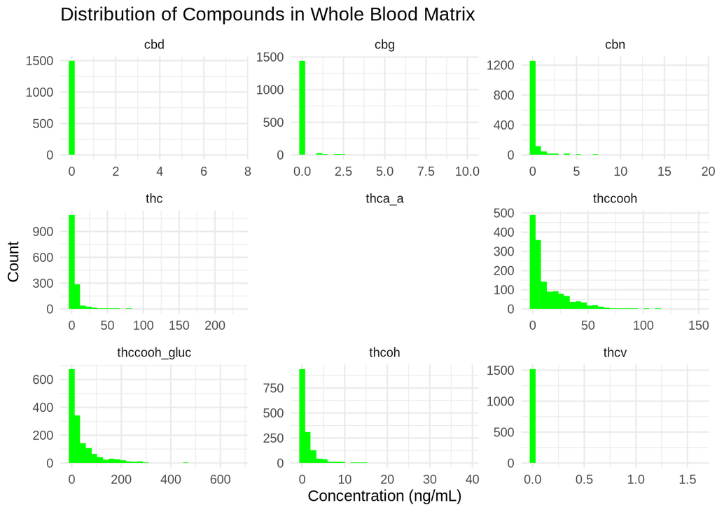

```r
cs01_long |>
  filter(fluid_type == "WB") |> # filter for the Whole blood fluid type
  ggplot(aes(x = value)) +
  geom_histogram(bins = 30, fill="green") +
  facet_wrap(~name, scales = "free") +
  labs(title = "Distribution of Compounds in Whole Blood Matrix",
       x = "Concentration (ng/mL)", y = "Count",
       fill = "Compound")
```

We are able to see that THC and its metabolites, such as THC-COOH, demonstrate higher concentrations and wider distributions in the WB matrix, suggesting their potential effectiveness as biomarkers for recent use.

Distribution of Compounds in Oral Fluid Matrix:

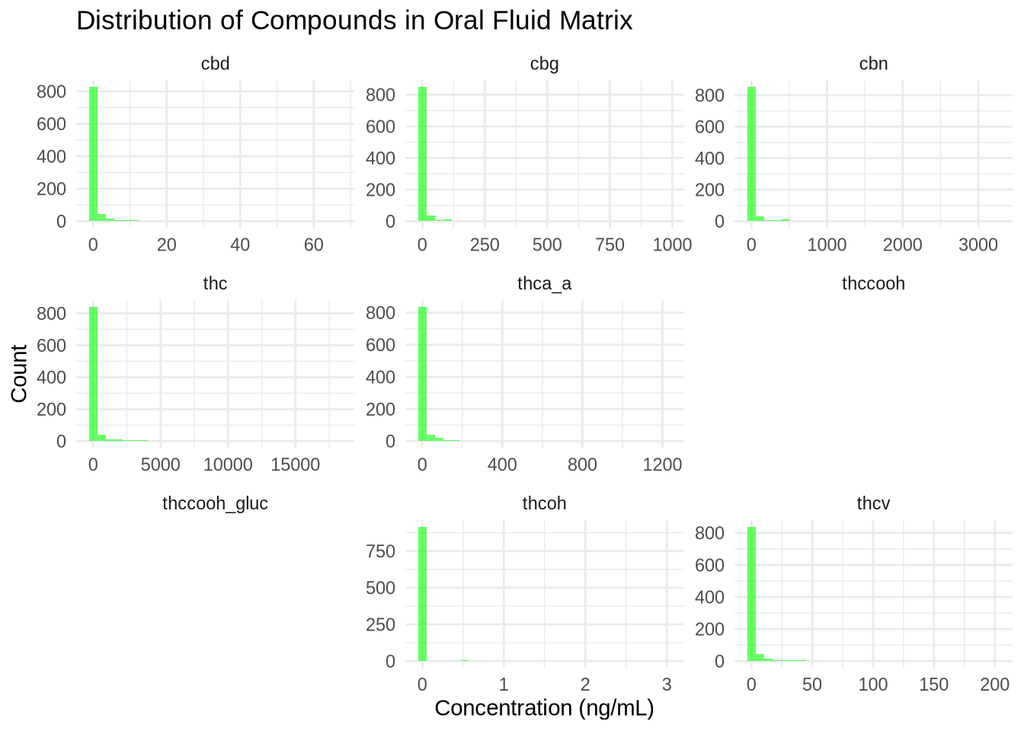

```r
cs01_long |>
  filter(fluid_type == "OF") |> # Filter for the Oral fluid type
  ggplot(aes(x = value)) +
  geom_histogram(bins = 30, fill="green", alpha = 0.6) +
  facet_wrap(~name, scales = "free") +
  labs(title = "Distribution of Compounds in Oral Fluid Matrix",
       x = "Concentration (ng/mL)", y = "Count",
       fill = "Compound")
```

It is clear that THC has a broad and detectable concentration range, making it a strong candidate for a primary biomarker of recent use, while other compounds, exhibit lower and narrower concentration ranges, indicating limited detectability and reliability as biomarkers in this matrix.

Distribution of Compounds in Breath Matrix:

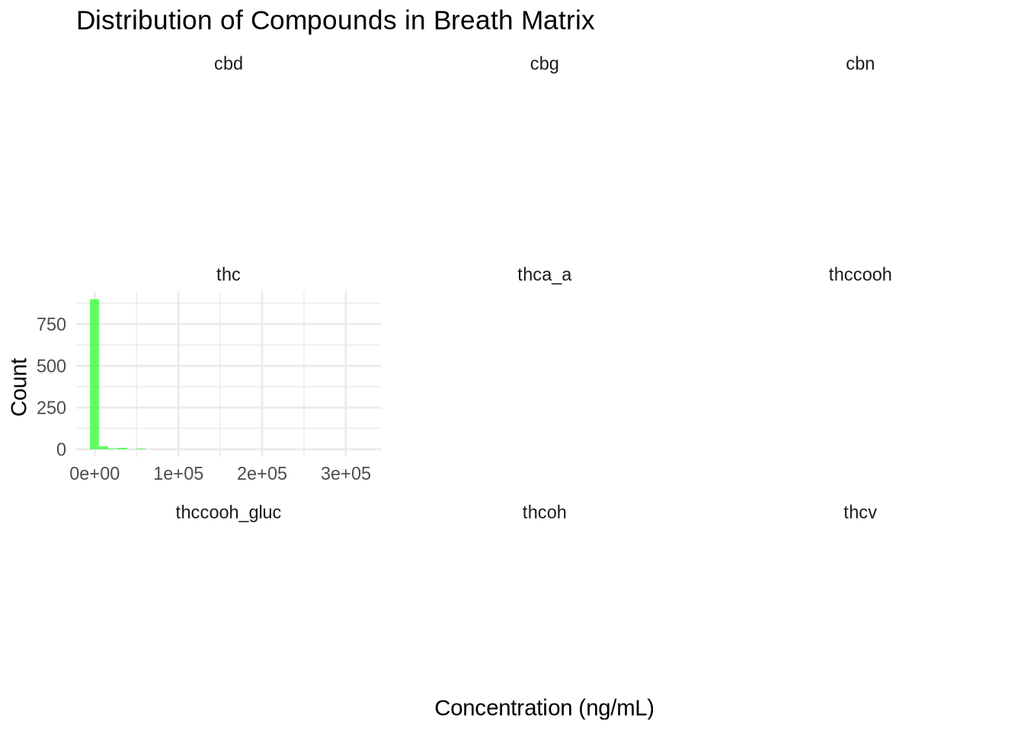

```r
cs01_long |>
  filter(fluid_type == "BR") |> # Filter for the Breath fluid type
  ggplot(aes(x = value)) +
  geom_histogram(bins = 30, fill="green", alpha = 0.6) +
  facet_wrap(~name, scales = "free") +
  labs(title = "Distribution of Compounds in Breath Matrix",
       x = "Concentration (ng/mL)", y = "Count",
       fill = "Compound")
```

THC is the only compound detected in the Breath matrix, showing a broad concentration range with relatively high counts, extending up to approximately 300,000. This suggests that THC is easily detectable in breath samples and could serve as a primary biomarker for recent cannabis use in this matrix.

This graph aims to compare how THC concentration levels change over time by each respective fluid type.

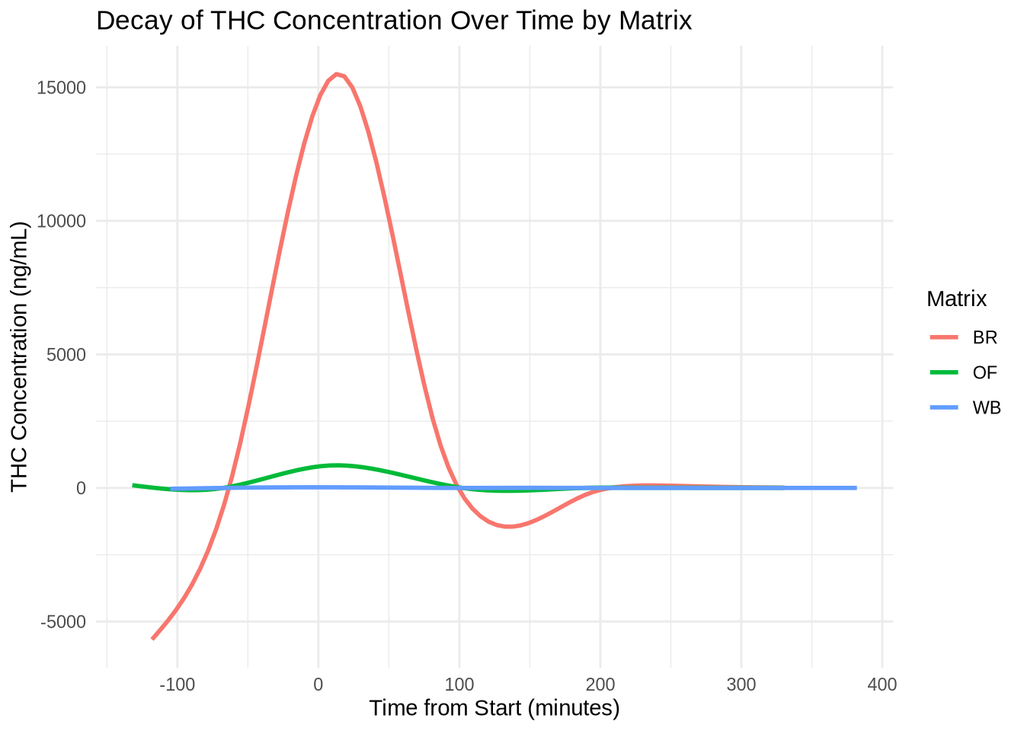

```r
cs01_long |>
  filter(name == "thc") |> # Filter for the THC compound
  ggplot(aes(x = time_from_start, y = value, color = fluid_type)) +
  geom_smooth(se = FALSE) +
  labs(title = "Decay of THC Concentration Over Time by Matrix",
       x = "Time from Start (minutes)", y = "THC Concentration (ng/mL)",
       color = "Matrix")
```

Breath shows a sharp, short-lived spike in THC concentration, ideal for detecting very recent use; oral fluid has a small increase with a slower decay, while whole blood seems to stay steady the whole way through.

We want to compare THC concentration over time across different matrices (Breath, Oral Fluid, and Whole Blood) and user groups (Frequent vs. Occasional) to get a sense of how they differ across fluid types and how they differ across groups.

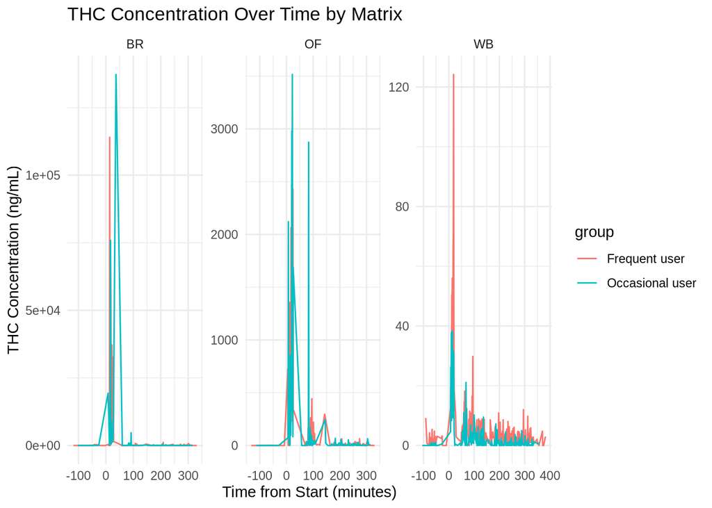

```r
cs01_long |>
  filter(name == "thc") |>
  ggplot(aes(x = time_from_start, y = value, color = group)) + # Distinguish between Frequent and Occasional users using color
  geom_line(stat = "summary", fun = mean) +
  facet_wrap(~fluid_type, scales = "free") +
  labs(title = "THC Concentration Over Time by Matrix",
       x = "Time from Start (minutes)", y = "THC Concentration (ng/mL)")
```

We see a consistent spike in THC concentration across the fluid types. The peaks that they reach vary immensely with breath reaching the highest levels, followed by oral fluid, then Whole blood. We see the biggest proportional discrepancy between the Frequent and Occasional user in the whole blood dataset.

## Data Analysis

The first thing we want to do is visualize the detection windows for THC by fluid type & user groups. This is because it helps us see the how long THC would be detectable in each fluid type for each group.

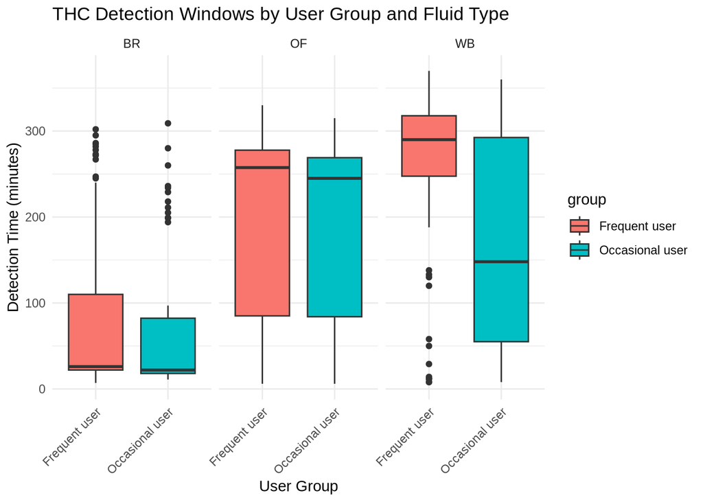

```r
# Calculate baseline values for each compound
baseline_values <- cs01_data %>%
  group_by(id, group, fluid_type) %>%
  summarize(
    thc_baseline = first(thc, default = NA),
    thcoh_baseline = first(thcoh, default = NA),
    thccooh_baseline = first(thccooh, default = NA),
    thccooh_gluc_baseline = first(thccooh_gluc, default = NA),
    .groups = "drop"
  )
cs01_data_with_baselines <- cs01_data %>%
  left_join(baseline_values, by = c("id", "group", "fluid_type"))

#Calculate detection windows
detection_analysis <- cs01_data_with_baselines %>%
  group_by(id, group, fluid_type) %>%
  summarize(
    thc_detection = max(time_from_start[thc > thc_baseline], na.rm = TRUE),
    thcoh_detection = max(time_from_start[thcoh > thcoh_baseline], na.rm = TRUE),
    thccooh_detection = max(time_from_start[thccooh > thccooh_baseline], na.rm = TRUE),
    thccooh_gluc_detection = max(time_from_start[thccooh_gluc > thccooh_gluc_baseline], na.rm = TRUE),
    .groups = "drop"
  )

#Visualize the detection times for THC by user group and fluid type
ggplot(detection_analysis, aes(x = group, y = thc_detection, fill = group)) +
  geom_boxplot() +
  facet_wrap(~fluid_type, scales = "fixed") +
  labs(
    title = "THC Detection Windows by User Group and Fluid Type",
    x = "User Group",
    y = "Detection Time (minutes)"
  ) + theme(axis.text.x = element_text(angle = 45, hjust = 1))
```

The detection window for breath shows that it is suitiable to determine if someone has been smoking in the last couple hours, which can be helpful in cases such as checking if someone is driving under the influence. While whole blood has a detection window of 1-5hrs for occasional users and 3.5-5hrs for frequent users. Which can be used to detect if someone had recently used cannabis rather than immediately.

Next we will do the t-test to check the statistical significance.

```r
blood_test <- t.test(thc_detection ~ group, data = detection_analysis |> filter(fluid_type == "WB", is.finite(thc_detection)))
oral_fluid_test <- t.test(thc_detection ~ group, data = detection_analysis |> filter(fluid_type == "OF"), is.finite(thc_detection))
breath_test <- t.test(thc_detection ~ group, data = detection_analysis |> filter(fluid_type == "BR"), is.finite(thc_detection))
```

Whole Blood t-test

```r
print(blood_test)
```

```
##
##  Welch Two Sample t-test
##
## data:  thc_detection by group
## t = 4.5711, df = 132.37, p-value = 1.1e-05
## alternative hypothesis: true difference in means between group Frequent user and group Occasional user is not equal to 0
## 95 percent confidence interval:
##   46.81386 118.23561
## sample estimates:
##   mean in group Frequent user mean in group Occasional user
##                      257.1585                      174.6338
```

The blood t-test had a extremely small p-value of 1.1e-5, which is smaller than 0.05. This means that this is strong evidence that it rejects the null hypothesis, and is statistically significant.

Oral Fluid t-test

```r
print(oral_fluid_test)
```

```
##
##  Welch Two Sample t-test
##
## data:  thc_detection by group
## t = 0.81947, df = 164.4, p-value = 0.4137
## alternative hypothesis: true difference in means between group Frequent user and group Occasional user is not equal to 0
## 95 percent confidence interval:
##  -19.35584  46.82125
## sample estimates:
##   mean in group Frequent user mean in group Occasional user
##                      202.9302                      189.1975
```

Breath t-Test

```r
print(breath_test)
```

```
##
##  Welch Two Sample t-test
##
## data:  thc_detection by group
## t = 2.1228, df = 137.71, p-value = 0.03556
## alternative hypothesis: true difference in means between group Frequent user and group Occasional user is not equal to 0
## 95 percent confidence interval:
##   2.195577 61.888964
## sample estimates:
##   mean in group Frequent user mean in group Occasional user
##                      95.01370                      62.97143
```

Breath had a p-value of 0.03556, which is less than 0.05. This means it is statistically significant, but not as statistically significant as Blood.

So while all both breath & blood are statistically significant, blood is more significant by far.

Next we want to look at the sensitivity at different THC cutoffs. This will allow us to find the threshold that can show recent use the best. From this we can see that blood has the biggest difference of sensitivity at varying cutoff levels. Breath and oral fluids both remain relatively constant on the other hand.

```r
cutoff_analysis <- cs01_data %>%
  filter(time_from_start > 0) %>%
  mutate(
    recent_use = time_from_start <= 120,
    detected_thc_5 = thc >= 5,
    detected_thc_10 = thc >= 10,
    detected_thc_15 = thc >= 15
  ) %>%
  group_by(group, fluid_type) %>%
  summarize(
    n_samples = n(),
    sensitivity_5ng = mean(detected_thc_5[recent_use], na.rm = TRUE),
    sensitivity_10ng = mean(detected_thc_10[recent_use], na.rm = TRUE),
    sensitivity_15ng = mean(detected_thc_15[recent_use], na.rm = TRUE),
    .groups = "drop"
  )
```

Below we will show a table of the sensitivity values:

```r
print(cutoff_analysis)
```

```
## # A tibble: 6 × 6
##   group   fluid_type n_samples sensitivity_5ng sensitivity_10ng sensitivity_15ng
##   <chr>   <chr>          <int>           <dbl>            <dbl>            <dbl>
## 1 Freque… BR               368           0.519            0.519            0.519
## 2 Freque… OF               356           0.655            0.603            0.569
## 3 Freque… WB               681           0.511            0.321            0.264
## 4 Occasi… BR               390           0.438            0.438            0.438
## 5 Occasi… OF               375           0.566            0.533            0.505
## 6 Occasi… WB               651           0.294            0.183            0.142
```

```r
plot_5ng <- ggplot(cutoff_analysis, aes(x = group, y = sensitivity_5ng, fill = fluid_type)) +
  geom_col(position = "dodge") +
  labs(
    title = "Sensitivity at 5 ng/mL THC Cutoff",
    x = "User Group",
    y = "Sensitivity",
    fill = "Fluid Type"
  )
```

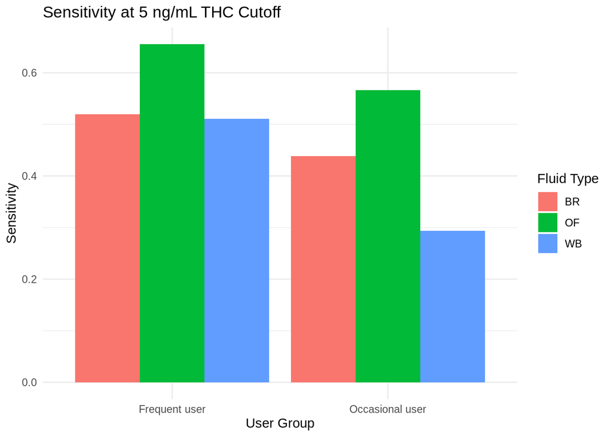

```r
plot_10ng <- ggplot(cutoff_analysis, aes(x = group, y = sensitivity_10ng, fill = fluid_type)) +
  geom_col(position = "dodge") +
  labs(
    title = "Sensitivity at 10 ng/mL THC Cutoff",
    x = "User Group",
    y = "Sensitivity",
    fill = "Fluid Type"
  )

plot_15ng <- ggplot(cutoff_analysis, aes(x = group, y = sensitivity_15ng, fill = fluid_type)) +
  geom_col(position = "dodge") +
  labs(
    title = "Sensitivity at 15 ng/mL THC Cutoff",
    x = "User Group",
    y = "Sensitivity",
    fill = "Fluid Type"
  )
print(plot_5ng)
```

For THC at a cutoff of 5 ng/mL, frequent users show a higher sensititvity than occasional users across all three fluid types

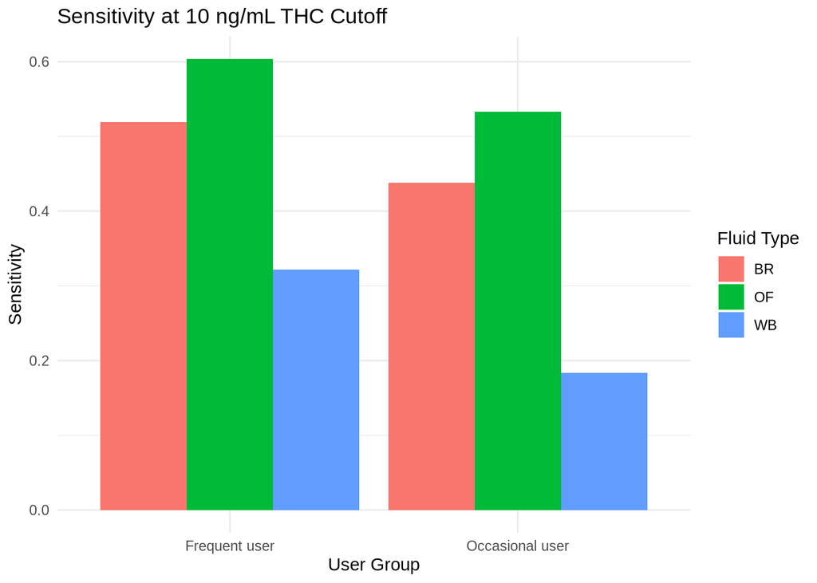

```r
print(plot_10ng)
```

For THC at a cutoff of 10 ng/mL, frequent users show a higher sensitivity than occasional users across all three fluid types

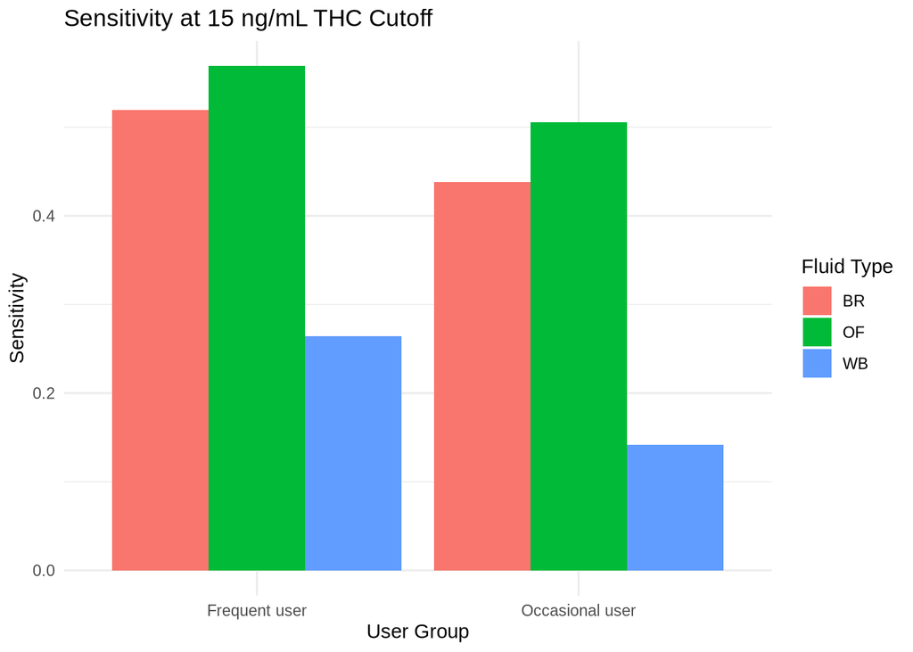

```r
print(plot_15ng)
```

Frequent users across all three fluid types have higher sensitivity than occasional users. But whole blood has the biggest drop off in sensitivity as the cutoffs increase. Breath remains constant, while Oral fluid decreases slightly with the increases in cutoff concentration.

## Results & Discussion

From our analysis, we found that the best bio marker for detecting recent cannabis use was THC in blood with a 5ng/ml cutoff. This is because THC levels in blood show significant change in sensitivity at each of the different cutoff times. Even though it had the lowest overall sensitivity of the three fluid types. That means that blood THC levels are the most responsive to cutoff threshold levels, and can show a difference between recent and non-recent use.

Based on the sensitivity data for the THC in blood 5ng/ml cutoff, we found that it varies significantly between frequent and occasional users. Of all three fluid types, whole blood also had the biggest difference in sensitivity between frequent (0.511) and occasional users (0.294) at 5ng/ml. This is likely due to the fact that frequent users have a higher baseline THC level, which would make it easier to detect THC above the 5ng/mL cutoff. This variation suggests that we should be cautious when interpreting results, because they need to be adjusted based on user frequency. Since occasional users may fall below the detection threshold more quickly despite recent use.

## Conclusion

Based on the given data, THC levels in whole blood are the most accurate biomarker and matrix for identifying recent cannabis use, particularly at a 5 ng/mL cutoff. Compared to oral fluid and breath, THC in whole blood showed significant sensitivity changes at different cutoff levels, making it more useful for differentiating between frequent and occasional use. The breath and oral fluid data more clearly identified very recent usage(up to the 100-minute mark), however, the whole blood offered a more stable detection window and a clear separation in THC levels between frequent and occasional users. It is important to note there were limitations that hindered our ability to accurately determine what compound was the best with the most notable being the lack of data in the breath dataset which only included the THC compound as well as a couple of compounds missing in the other data as well. Taking that into account, our findings suggest that whole blood THC at 5 ng/mL is the optimal marker for recent cannabis use.

## Sources

1. Abuse, National Institute on Drug. Cannabis (Marijuana) | National Institute on Drug Abuse (NIDA). 24 Sept. 2024, https://nida.nih.gov/research-topics/cannabis-marijuana.
2. Cannabis | FRANK. https://www.talktofrank.com/drug/cannabis. Accessed 6 Nov. 2024.
3. CANNABIS: Overview, Uses, Side Effects, Precautions, Interactions, Dosing and Reviews. https://www.webmd.com/vitamins/ai/ingredientmono-947/cannabis. Accessed 6 Nov. 2024.
4. “CBD: Does It Work? Is It Safe? Is It Legal?” AAMC, https://www.aamc.org/news/cbd-does-it-work-it-safe-it-legal. Accessed 6 Nov. 2024.
5. CDC. “State Medical Cannabis Laws.” Cannabis and Public Health, 26 Feb. 2024, https://www.cdc.gov/cannabis/about/state-medical-cannabis-laws.html.
6. Compton, Richard, and Amy Berning. Results of the 2007 National Roadside Survey of Alcohol and Drug Use by Drivers [Traffic Safety Facts]. Edited by National Center for Statistics and Analysis (U.S.), DOT HS 811 175, 1 July 2009. ROSA P, https://rosap.ntl.bts.gov/view/dot/1913.
7. “How Long Does Marijuana (Weed) Stay in Your System?” American Addiction Centers, https://americanaddictioncenters.org/marijuana-rehab/how-long-system-body. Accessed 6 Nov. 2024.
8. Staver, Jared. “Marijuana Causes More Car Crashes | Staver Accident Injury Lawyers, P.C.” Staver, 4 Aug. 2015, https://www.chicagolawyer.com/blog/does-smoking-marijuana-cause-more-car-crashes/.
9. Where Is Marijuana Legal in the U.S.? | Legality, States, Medicinal Use, Adult Use, & Decriminalization | Britannica. 6 Nov. 2024, https://www.britannica.com/topic/US-marijuana-laws-by-state.